# Colchicine

### Robustnees test with increased COLOCT variability

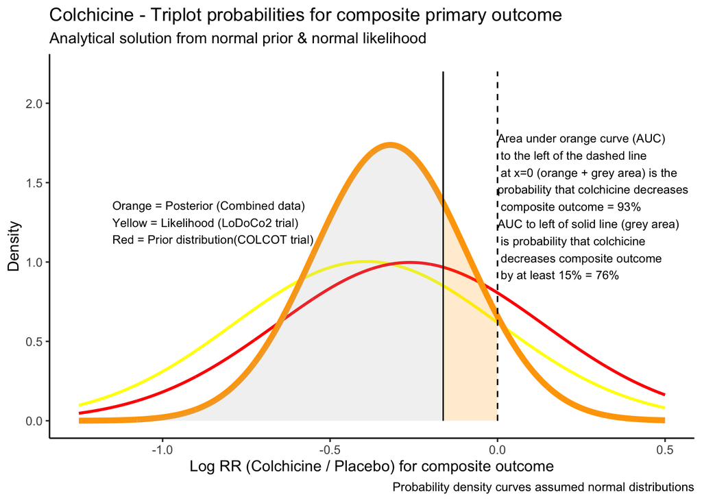

```r
# different prior increased variation
analytical <- post(exp(m1$TE.random), m1$seTE.random, .77, .4)
# pnorm(0, log(analytical[[1]]), analytical[[2]])
# pnorm(-.1625, log(analytical[[1]]), analytical[[2]]) 15% reduction = log(.85)
# 1- pnorm(0, log(.77), .3)

g_an_2 <- ggplot(data = data.frame(x = c(-1.25, .5)), aes(x)) +
  stat_function(fun = dnorm, args = list(bma$summary[3,2], bma$summary[4,2]),  colour = "yellow", size=1) +
  stat_function(fun = dnorm, n = 1000, args = list(mean = log(.77), sd = .4), size=1, color = "red") +
  stat_function(fun = dnorm, n = 1000, args = list(log(analytical[[1]]), analytical[[2]]), color = "orange", size=2)  +
  scale_x_continuous(name = "Log RR (Colchicine / Placebo) for composite outcome") +
  scale_y_continuous(name = "Density") +
  ggtitle("Colchicine - Triplot probabilities for composite primary outcome")  +
  labs(x = "Log (RR)", caption = "Probability density curves assumed normal distributions", subtitle = "Analytical solution from normal prior & normal likelihood") +
  annotate("text", size=3, label = "Orange = Posterior (Combined data) \nYellow = Likelihood (LoDoCo2 trial) \nRed = Prior distribution(COLCOT trial)", x = -1.15, y = 1.25, hjust = 0, color = "black") +
  annotate("text", size=3, label = "Area under orange curve (AUC)\n to the left of the dashed line\n at x=0 (orange + grey area) is the \nprobability that colchicine decreases\n composite outcome = 93%\nAUC to left of solid line (grey area)\n is probability that colchicine\n decreases composite outcome\n by at least 15% = 76%", x = 0, y = 1.35, hjust = 0, color = "black") +
  geom_segment(aes(x = 0, y = 0, xend = 0, yend = 2.2), linetype="dashed",  size=.5) +
  geom_segment(aes(x = -.1625, y = 0, xend = -.1625, yend = 2.2), linetype="solid",  size=.5) +
  theme_classic()  +
  stat_function(fun = dnorm, args = list(log(analytical[[1]]), analytical[[2]]), xlim = c(-1.25,-.1625), geom = "area", fill= "gray",alpha = 0.2) +
  stat_function(fun = dnorm, args = list(log(analytical[[1]]), analytical[[2]]), xlim = c(-.1625, 0), geom = "area", fill= "orange",alpha = 0.2)

g_an_2
```

```r
pdf("output/g_an_2.pdf")
g_an_2
dev.off()
```

```r
ggsave("output/g_an_2.png")
```

### Triplot using `bayesmeta` package

A wide range of problems may be approached using the normal-normal hierarchical model (NNHM); a generic random-effects model that can be operationalized using the `bayesmeta` package. For random-effects meta-analysis within the NNHM, where only two unkown parameters are to be inferred, computations may be simplified by utilizing numerical integration or importance resampling, without need for MCMC techniques.  
- here the posterior mean and sd are calculated from the `bayesmeta` function

```r
# Total data
# Use a vague prior centered at 0, which corresponds to an OR of 1, i.e., no effect.
# The prior standard deviation has been assumed to be a half-normal prior with scale 0.03
# posterior
# pnorm(0, comb1.mean, comb1.sd)
# pnorm(-.1625, comb1.mean, comb1.sd) 15% reduction = log(.85)
# pnorm(0, comb2.mean, comb2.sd)
# pnorm(-.1625, comb2.mean, comb2.sd) 15% reduction = log(.85)



ma_tot1 <- bayesmeta(y = comb[,"lrr"], sigma = comb[,"lse"],
                  labels = comb[,"study"], mu.prior.mean = 0, mu.prior.sd = 2,
                  tau.prior = function(t){dhalfnormal(t,scale=0.03)})


comb1.mean <- ma_tot1$summary[3,2]
comb1.sd <-  ma_tot1$summary[4,2]
ma_tot1$summary
```

```
##               tau       mu    theta
## mode      0.00000 -0.30827 -0.30815
## median    0.02432 -0.30834 -0.30828
## mean      0.02826 -0.30838 -0.30838
## sd        0.02076  0.07417  0.08192
## 95% lower 0.00000 -0.45386 -0.46980
## 95% upper 0.06790 -0.16290 -0.14705
```

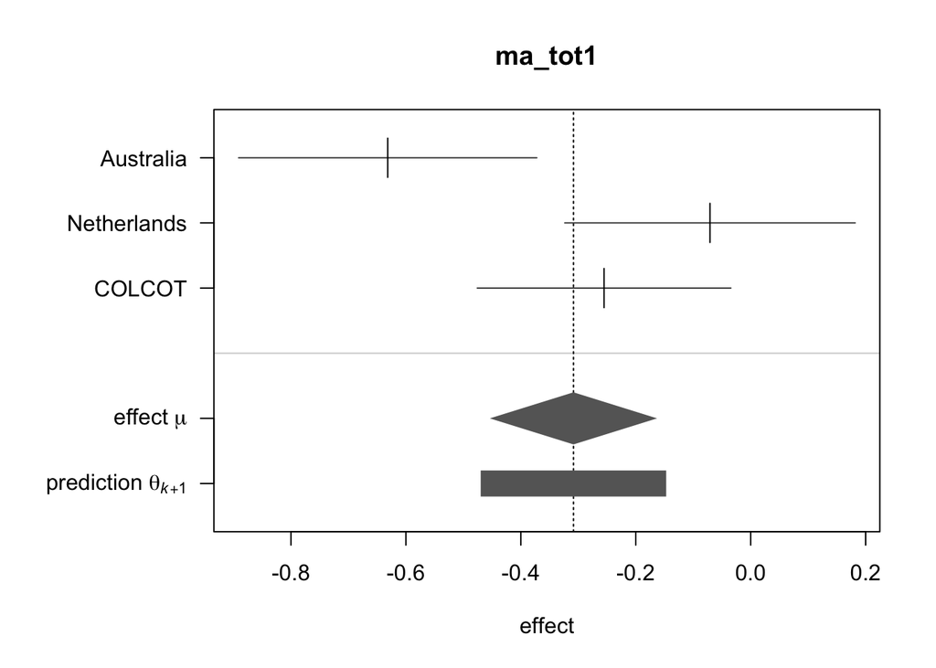

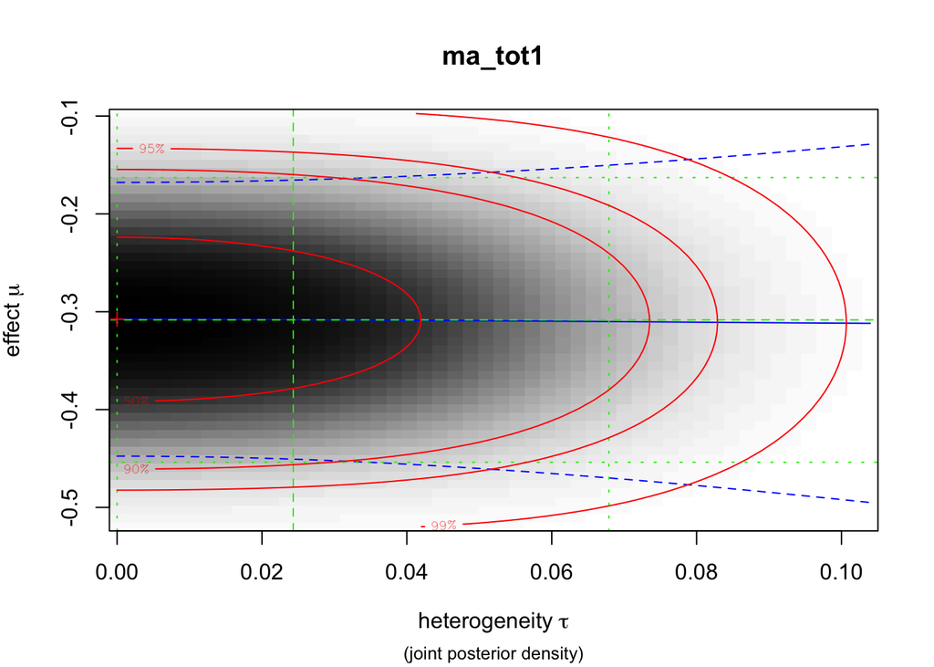

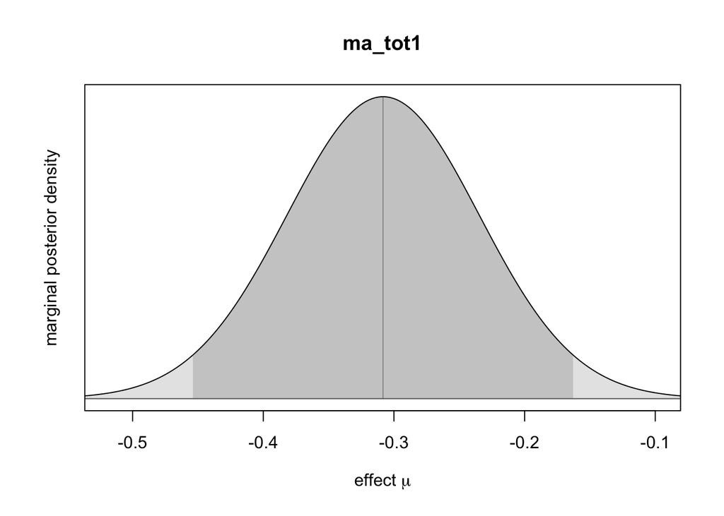

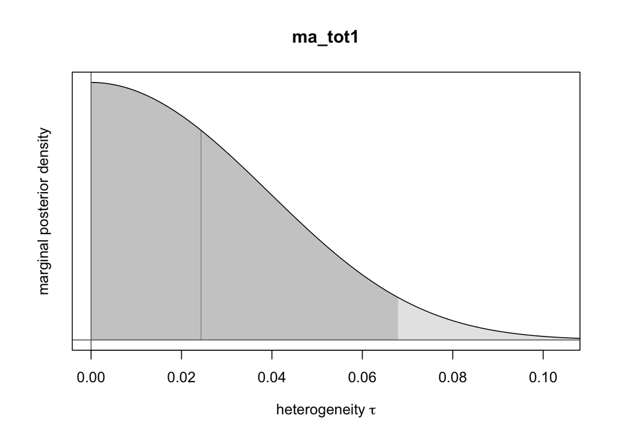

```r
plot(ma_tot1)
```

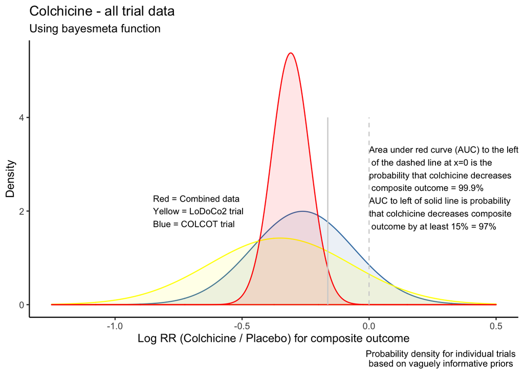

```r
#1/2 data prior

ma_tot2 <- bayesmeta(y = comb2[,"lrr"], sigma = comb2[,"lse"],
                  labels = comb2[,"study"], mu.prior.mean = 0, mu.prior.sd = 2,
                  tau.prior = function(t){dhalfnormal(t,scale=0.03)})


comb2.mean <- ma_tot2$summary[3,2]
comb2.sd <-  ma_tot2$summary[4,2]

#graphs

g_bayes1 <- ggplot(data = data.frame(x = c(-1.25, .5)), aes(x)) +
  stat_function(fun = dnorm, n = 1000, args = list(mean = log(.77), sd = .2), geom = "area", color = "steelblue", fill = "steelblue", alpha=.1) +
  stat_function(fun = dnorm, n = 1000, args = list(mean = m1$TE.random, sd = m1$seTE.random), geom = "area", color = "yellow", fill = "yellow", alpha=.1, xlim = c(-1.25,.5)) +
  stat_function(fun = dnorm, n = 1000, args = list(comb1.mean,comb1.sd), , geom = "area", color = "red",
                fill = "red", alpha=.1, xlim = c(-1.25,.5))  +
    scale_x_continuous(name = "Log RR (Colchicine / Placebo) for composite outcome") +
    scale_y_continuous(name = "Density") +
    ggtitle("Colchicine - all trial data")  +
    labs(x = "Log (RR)", caption = "Probability density for individual trials \nbased on vaguely informative priors  ", subtitle = "Using bayesmeta function") +
  annotate("text", size=3, label = "Red = Combined data \nYellow = LoDoCo2 trial \nBlue = COLCOT trial", x = -.85, y = 2, hjust = 0, color = "black") +
  annotate("text", size=3, label = "Area under red curve (AUC) to the left\n of the dashed line at x=0 is the \nprobability that colchicine decreases\n composite outcome = 99.9%\nAUC to left of solid line is probability\nthat colchicine decreases composite\n outcome by at least 15% = 97%", x = 0, y = 2.5, hjust = 0, color = "black") +
  geom_segment(aes(x = 0, y = 0, xend = 0, yend = 4), linetype="dashed", color = "light gray", size=.5) +
  geom_segment(aes(x = -.1625, y = 0, xend = -.1625, yend = 4), linetype="solid", color = "light gray", size=.5) +
    theme_classic()

g_bayes1
```

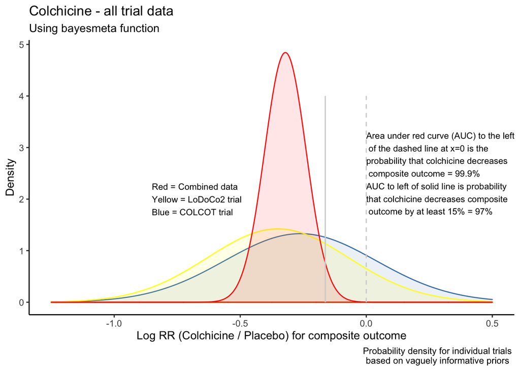

```r
#1/2 prior

g_bayes2 <- ggplot(data = data.frame(x = c(-1.25, .5)), aes(x)) +
  stat_function(fun = dnorm, n = 1000, args = list(mean = log(.77), sd = .3), geom = "area", color = "steelblue", fill = "steelblue", alpha=.1) +
  stat_function(fun = dnorm, n = 1000, args = list(mean = m1$TE.random, sd = m1$seTE.random), geom = "area", color = "yellow", fill = "yellow", alpha=.1, xlim = c(-1.25,.5)) +
  stat_function(fun = dnorm, n = 1000, args = list(comb2.mean,comb2.sd), , geom = "area", color = "red",
                fill = "red", alpha=.1, xlim = c(-1.25,.5))  +
    scale_x_continuous(name = "Log RR (Colchicine / Placebo) for composite outcome") +
    scale_y_continuous(name = "Density") +
    ggtitle("Colchicine - all trial data")  +
    labs(x = "Log (RR)", caption = "Probability density for individual trials \nbased on vaguely informative priors  ", subtitle = "Using bayesmeta function") +
  annotate("text", size=3, label = "Red = Combined data \nYellow = LoDoCo2 trial \nBlue = COLCOT trial", x = -.85, y = 2, hjust = 0, color = "black") +
  annotate("text", size=3, label = "Area under red curve (AUC) to the left\n of the dashed line at x=0 is the \nprobability that colchicine decreases\n composite outcome = 99.9%\nAUC to left of solid line is probability\nthat colchicine decreases composite\n outcome by at least 15% = 97%", x = 0, y = 2.5, hjust = 0, color = "black") +
  geom_segment(aes(x = 0, y = 0, xend = 0, yend = 4), linetype="dashed", color = "light gray", size=.5) +
  geom_segment(aes(x = -.1625, y = 0, xend = -.1625, yend = 4), linetype="solid", color = "light gray", size=.5) +
    theme_classic()

g_bayes2
```